# Reproducible Research: Peer Assessment 1

Aamer Shaikh  
GitHub: https://github.com/aamershaikh1990/RepData_PeerAssessment1

## Loading and preprocessing the data

Reading in data from the activity zip file.

```r
unzip("activity.zip")
dataset <- read.csv("activity.csv")
```

## What is mean total number of steps taken per day?

1. Histogram of the total number of steps taken each day

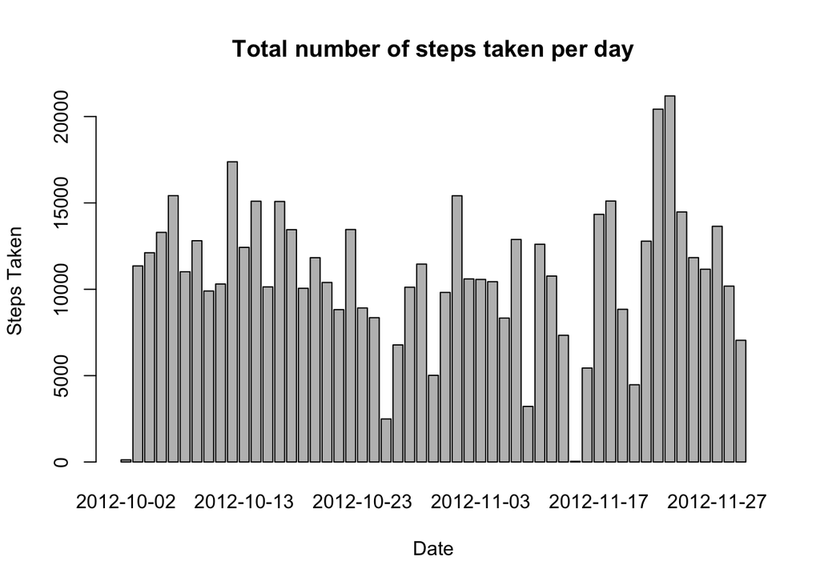

```r
steps_date<- aggregate(steps ~ date, data=dataset, FUN=sum)
barplot(steps_date$steps, names.arg=steps_date$date, xlab="Date", ylab="Steps Taken", main = "Total number of steps taken per day")
```

2. Calculated **mean** and **median** of total number of steps taken per day

```r
mean(steps_date$steps)
```

```
## [1] 10766
```

```r
median(steps_date$steps)
```

```
## [1] 10765
```

## What is the average daily activity pattern?

1. Time series plot of the 5-minute interval and average number of steps taken, averaged across all days.

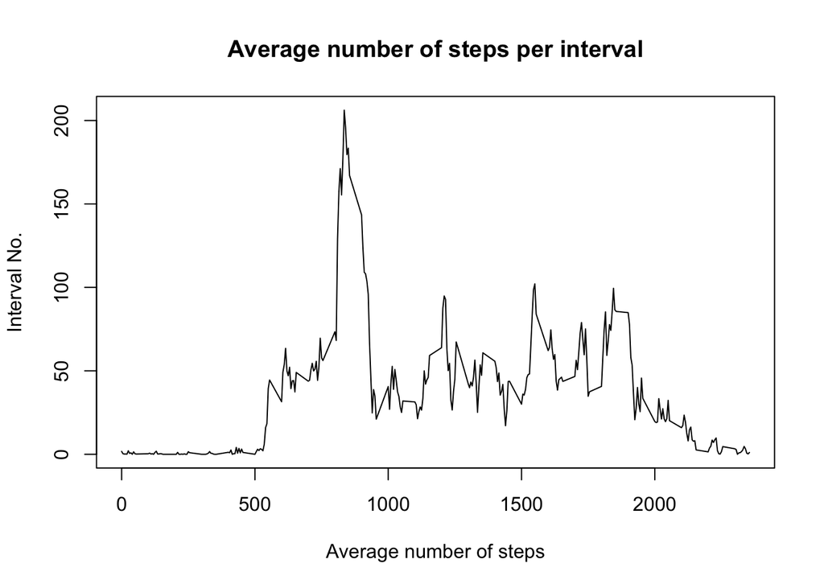

```r
interval <- aggregate(steps ~ interval, data=dataset, FUN=mean)
plot(interval, type="l", xlab = "Average number of steps", ylab = "Interval No.", main = "Average number of steps per interval")
```

2. Which 5-minute interval, averaged across all the days contained the max number of steps?

```r
interval$interval[which.max(interval$steps)]
```

```
## [1] 835
```

Interval number **835** contained the max number of average steps

## Imputing missing values

1. Calculating the total number of missing values in the dataset (i.e. the total number of rows with `NA`s)

```r
sum(is.na(dataset))
```

```
## [1] 2304
```

2.Devising a strategy for filling in all of the missing values in the dataset. The strategy does not need to be sophisticated. For example, you could use the mean/median for that day, or the mean for that 5-minute interval, etc.

I will be using the mean for the 5-minute interval in order to fill any rows that do not have a value for number of steps taken in that interval

3. Create a new dataset that is equal to the original dataset but with the missing data filled in.

```r
## Merge the dataset with the intervals dataset
dataset <- merge(dataset, interval, by="interval", suffixes=c("",".aggregate"))

## Store all the NA's in a vector
all_na <- is.na(dataset$steps)

## Use the NA vector to index all the missing positions and replace them with the 5-minute interval mean value
dataset$steps[all_na] <- dataset$steps.aggregate[all_na]

## Restore the dataset to the original 3 columns only
dataset <- dataset[,c(1:3)]
```

4. Make a histogram of the total number of steps taken each day and calculate and report the **mean** and **median** total number of steps taken per day. Do these values differ from the estimates from the first part of the assignment? What is the impact of imputing missing data on the estimates of the total daily number of steps?

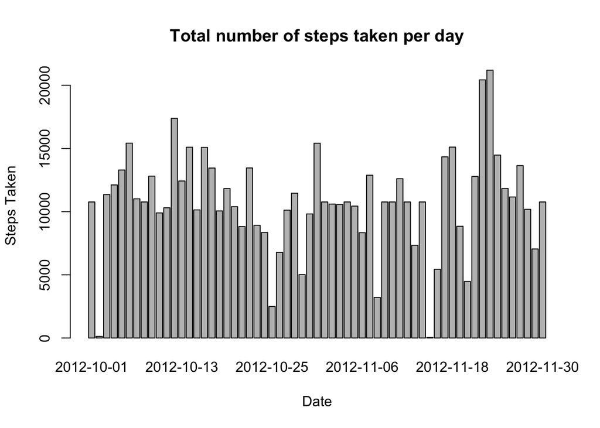

```r
steps_date<- aggregate(steps ~ date, data=dataset, FUN=sum)
barplot(steps_date$steps, names.arg=steps_date$date, xlab="Date", ylab="Steps Taken", main = "Total number of steps taken per day")
```

```r
mean(steps_date$steps)
```

```
## [1] 10766
```

```r
median(steps_date$steps)
```

```
## [1] 10766
```

The impact of the missing data seems negligible as, it has had no impact on the mean. Additionally, the estimates of total number of steps per day do not seem to be very different.

## Are there differences in activity patterns between weekdays and weekends?

1. Creating a new factor variable in the dataset with two levels – “weekday” and “weekend” indicating whether a given date is a weekday or weekend day.

```r
daytype <- function(date){
  if(weekdays(as.Date(date)) %in% c("Saturday","Sunday")){
    "weekend"
  } else{
    "weekday"
  }
}

dataset$day_type <- as.factor(sapply(dataset$date, daytype))
```

2. Making a panel plot containing a time series plot of the 5-minute interval and the average number of steps taken, averaged across all weekday days or weekend days.

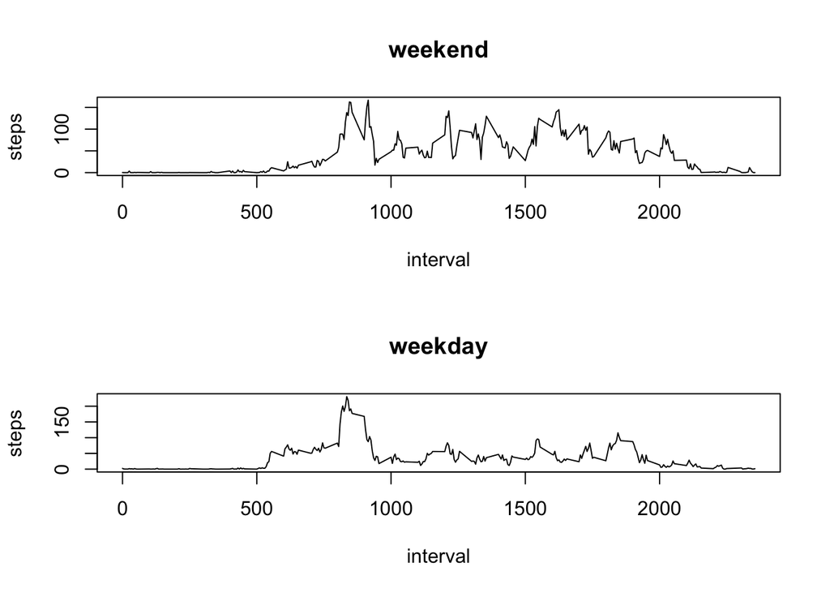

```r
## Creating a matrix of two rows
par(mfrow=c(2,1))

## Creating two plots that are subsetted by 'weekday' and 'weekend'
for (type in c("weekend", "weekday")) {
    steps_type <- aggregate(steps ~ interval,data=dataset, subset= (dataset$day_type==type),FUN=mean)
    plot(steps_type, type="l", main=type)
}
```